# Impact of Route Efficiency and Stopovers on Airline Fare Pricing

Jingwei Zhao

Jyovika Aswale

Rimlan Alva

# Problem introduction

✈ **Airline Fare Pricing & Route Efficiency**

The airline industry shows big differences in fare prices, shaped by:

- Route efficiency
- Flight characteristics

This study explores:

- 💡 Does higher circuity (more indirect paths) mean **higher fare per mile**?
- 💡 Are **nonstop flights** more expensive than flights with stopovers?

Understanding these patterns helps explain airline pricing strategies and sets realistic fare expectations for travelers.

# Dataset description

- 📦 **Source:**  
  US Department of Transportation — Bureau of Transportation Statistics (BTS)
- 🗂 **Size:**  
  1,581,278 rows × 26 columns
- 🔍 **Key variables:**
  - Route features (circuity, nonstop miles)
  - Flight details (carrier, roundtrip, market share)
  - Competition (market HHI, LCC presence, multi-airport)
- 💡 **Datasets included:**  
  DB1B + T-100 (cleaned + merged)

# Methods

# Results

- **Nonstop, low circuity flights:** highest fare per mile (**0.247**)
- **High circuity, with stops:** higher fare (**0.173**) than low circuity, with stops (**0.161**)
- No nonstop flights in high circuity group
- Plot highlights clear pricing patterns

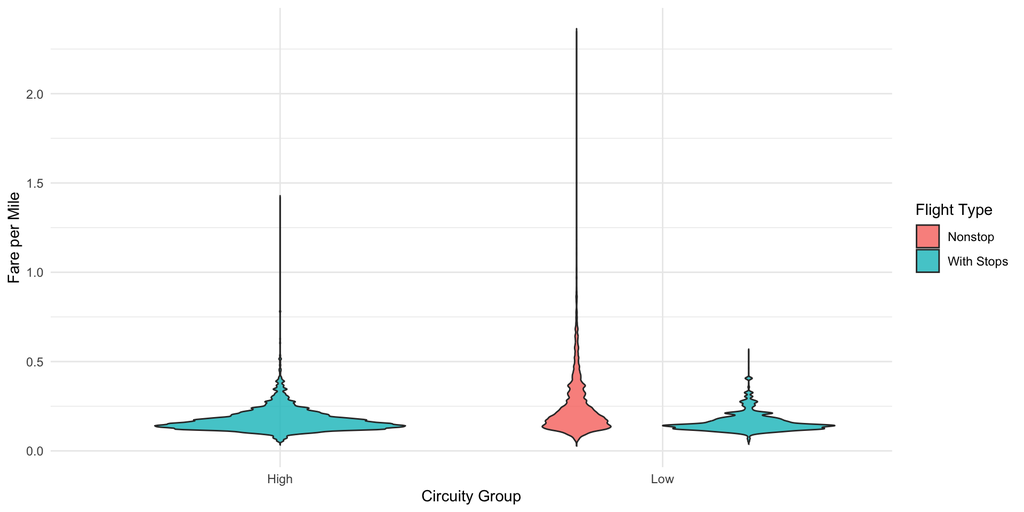

Distribution of fare per mile by circuity group and stop type

# Conclusions

- ✈️ **Nonstop, low-circuity flights** have the **highest fare per mile** — travelers pay more for speed and convenience.
- 🔁 **Higher circuity** (indirect) routes cost **more per mile**, even when they include stopovers.
- 🚫 **No nonstop flights** exist in high-circuity routes — airlines avoid inefficient direct paths.

📌 **Key Insight**  
Fare pricing reflects both **route efficiency** and **flight type**.  
Stopovers don’t always reduce fares — especially on inefficient routes.

# Recommendations

📢 **Practical Guidance:**

- 💰 **Budget travelers** → choose **low-circuity routes with stopovers** for best value.
- ✈️ **Airlines** → use circuity data to refine **pricing and route planning**.
- 📊 **Analysts** → investigate **market share**, **LCC presence**, and **multi-airport markets** as additional drivers of fare differences.